# ETL - TV Show Recommender Systems by Tom Shanahan

The data contains information about TV shows viewing habits. The dataset contains binary information as to whether a user has viewed a show in three month period. It includes 9985 users and 563 popular TV shows.

# Extracting Data:

**Step 1:** Loading tv show title and review dataset.  
**Step 2:** Loading IMDB dataset with show genre information.  
**Step 3:** Merging IMDB genre data to given show titles.

```python
import math
import json
import numpy as np
import pandas as pd
import matplotlib.pyplot as plt
from sklearn.manifold import TSNE
from scipy.linalg import svd as svd
# from scipy.spatial import Voronoi, voronoi_plot_2d
from google.colab import files, drive

drive.mount('/content/drive/')

shows = []
with open('/content/drive/My Drive/Colab Notebooks/Data ETL/input data/shows.txt', 'r') as input_file:
    for input_line in input_file:
        shows.append(input_line.strip()[1:-1])

reviews = np.loadtxt('/content/drive/My Drive/Colab Notebooks/Data ETL/input data/user-shows.txt', dtype='int')

imdb_data = pd.read_csv('/content/drive/My Drive/Colab Notebooks/Data ETL/input data/title.basics.tsv', sep='\t')
imdb_data = imdb_data[imdb_data['titleType'] == 'tvSeries']
imdb_data = imdb_data[['originalTitle','genres']]

shows_pd = pd.DataFrame(shows,columns=["title"])

shows_genre = pd.merge(shows_pd, imdb_data, how='left', left_on='title', right_on='originalTitle')
shows_genre.drop_duplicates(subset="title", keep='first', inplace=True, ignore_index=True)
shows_genre = shows_genre[['title','genres']]
```

# Transforming Data:

**Step 1:** Data cleaning (luckily the data is pretty clean, so not much to do).  
**Step 2:** Generating item similarity matrix for tv shows.

```python
# Step 1:
### Sex & the City appears twice, deleting one instance of the show
reviews = np.delete(reviews, 474, axis=1)
del shows[474]

# Step 2:
### generate empty matrices
users, items = reviews.shape
user_user_matrix = np.zeros(shape=(users, users), dtype='int')
show_show_matrix = np.zeros(shape=(items, items), dtype='int')

# populate user-user, show-show matrices
reviews_show = np.sum(reviews, axis=0)
reviews_user = np.sum(reviews, axis=1)

for u in range(users):
    user_user_matrix[u][u] = reviews_user[u]

for i in range(items):
    show_show_matrix[i][i] = reviews_show[i]

reviews_T = np.transpose(reviews)
RtR = np.matmul(reviews_T, reviews)
RRt = np.matmul(reviews, reviews_T)

show_inv_sqrt = np.linalg.inv(np.sqrt(show_show_matrix))
item_sim1 = np.matmul(show_inv_sqrt, RtR)
item_sim = np.matmul(item_sim1, show_inv_sqrt)
```

# User-User Recommendation Engine with Collaborative Filtering:

Collaborative filtering relies on the reactions of similar users to identify items a particular user may like.

**Step 1:** Compute P (user_count x user_count) matrix whose i-th diagonal element is the degree of user node (number of items that user i likes).  
**Step 2:** Compute Q (show_count x show_count) matrix ,whose i-th diagonal element is the degree of item node i (number of users that liked item i).  
**Step 3:** Using User-User similarity matrix generated above and newly created P, Q, multiple the matrix to find the expected item review for a given user.

```python
# user similarity matrix
user_inv_sqrt = np.linalg.inv(np.sqrt(user_user_matrix))
user_sim1 = np.matmul(user_inv_sqrt, RRt)
user_sim = np.matmul(user_sim1, user_inv_sqrt)
user_sim_review = np.matmul(user_sim, reviews)
alex_top_user = (-user_sim_review[499][0:100]).argsort()[:5]

# output results
fp = open('Part A (user,user).txt', 'w+')

print("User – User Recommender System: Top 5 Recommendations for Alex:")
print("User – User Recommender System: Top 5 Recommendations for Alex:", file=fp)
for i in range(5):
    print("\t Similarity: %.4f" % (user_sim_review[499][alex_top_user[i]]), "\t Show: ", shows[alex_top_user[i]])
    print("\t Similarity: %.4f" % (user_sim_review[499][alex_top_user[i]]), "\t Show: ", shows[alex_top_user[i]], file=fp)

fp.close()
```

```
User – User Recommender System: Top 5 Recommendations for Alex:
	 Similarity: 908.8028 	 Show:  FOX 28 News at 10pm
	 Similarity: 861.5133 	 Show:  Family Guy
	 Similarity: 827.9569 	 Show:  2009 NCAA Basketball Tournament
	 Similarity: 785.0808 	 Show:  NBC 4 at Eleven
	 Similarity: 757.8951 	 Show:  Two and a Half Men
```

# Item-Item Recommendation Engine with Collaborative Filtering:

```python
# show similarity matrix
show_inv_sqrt = np.linalg.inv(np.sqrt(show_show_matrix))
item_sim1 = np.matmul(show_inv_sqrt, RtR)
item_sim = np.matmul(item_sim1, show_inv_sqrt)
item_sim_review = np.matmul(reviews, item_sim)
alex_top_item = (-item_sim_review[499][0:100]).argsort()[:5]

# output results
fp = open('Part B (item,item).txt', 'w+')

print("Item – Item Recommender System: Top 5 Recommendations for Alex:")
print("Item – Item Recommender System: Top 5 Recommendations for Alex:", file=fp)
for i in range(5):
    print("\t Similarity: %.4f" % (item_sim_review[499][alex_top_item[i]]), "\t Show: ", shows[alex_top_item[i]])
    print("\t Similarity: %.4f" % (item_sim_review[499][alex_top_item[i]]), "\t Show: ", shows[alex_top_item[i]], file=fp)

fp.close()
```

```
Item – Item Recommender System: Top 5 Recommendations for Alex:
	 Similarity: 31.3647 	 Show:  FOX 28 News at 10pm
	 Similarity: 30.0011 	 Show:  Family Guy
	 Similarity: 29.3968 	 Show:  NBC 4 at Eleven
	 Similarity: 29.2270 	 Show:  2009 NCAA Basketball Tournament
	 Similarity: 28.9713 	 Show:  Access Hollywood
```

## Transforming Data (Cont'd):

```
[t-SNE] Computing 121 nearest neighbors...
[t-SNE] Indexed 562 samples in 0.028s...
[t-SNE] Computed neighbors for 562 samples in 0.429s...
[t-SNE] Computed conditional probabilities for sample 562 / 562
[t-SNE] Mean sigma: 0.778538
[t-SNE] KL divergence after 250 iterations with early exaggeration: 58.786129
[t-SNE] KL divergence after 300 iterations: 0.487403
```

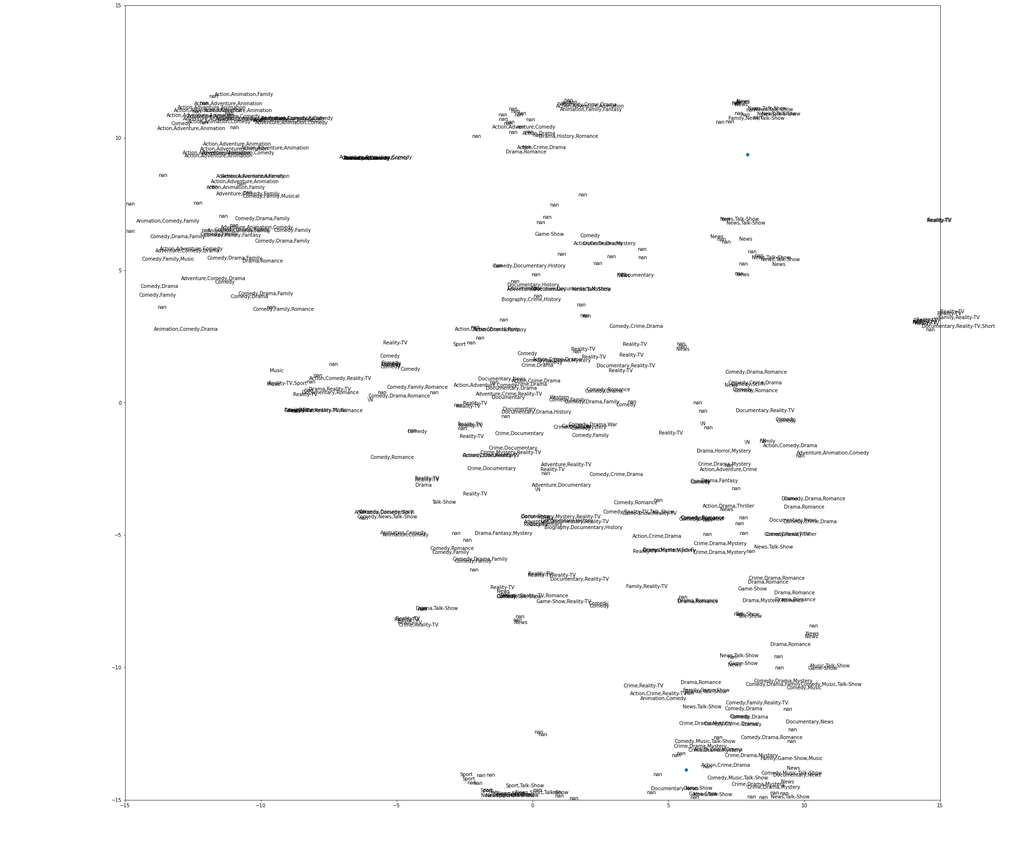

```python
# Step 3:
data = pd.DataFrame(item_sim)
tsne = TSNE(n_components=2, verbose=1, perplexity=40, n_iter=300)
tsne_results = tsne.fit_transform(data)

# Step 4:
results = pd.DataFrame()
results['label'] = shows_genre.iloc[:,0]
results['genres'] = shows_genre.iloc[:,1]
results['tsneCoordinates'] = tsne_results.tolist()
results['similarityMatrix'] = item_sim.tolist()

# Step 5:
xSeries = [i[0] for i in results['tsneCoordinates']]
ySeries = [i[1] for i in results['tsneCoordinates']]
x_min, x_max = min(xSeries),max(xSeries)
y_min, y_max = min(ySeries),max(ySeries)

results['tsneCoordinatesNormalized'] = [[(i-x_min)/(x_max-x_min),(j-y_min)/(y_max-y_min)] for i,j in zip(xSeries,ySeries)]

# Step 6:
plt.figure(figsize=(30, 30))
plt.scatter(results['tsneCoordinates'][0], results['tsneCoordinates'][1])
plt.axis([-15, 15, -15, 15])

for i, genre in enumerate(results["genres"]):
    plt.annotate(genre, (tsne_results[i][0], tsne_results[i][1]))

plt.savefig('tsne_genre_cloud.pdf')
```

## Transforming Data (Cont'd):

**Step 7: Generating RBG values for voronoi plot.** .

```python
def hsv2rgb(h, s, v):
    h = float(h)
    s = float(s)
    v = float(v)
    h60 = h / 60.0
    h60f = math.floor(h60)
    hi = int(h60f) % 6
    f = h60 - h60f
    p = v * (1 - s)
    q = v * (1 - f * s)
    t = v * (1 - (1 - f) * s)
    r, g, b = 0, 0, 0
    if hi == 0: r, g, b = v, t, p
    elif hi == 1: r, g, b = q, v, p
    elif hi == 2: r, g, b = p, v, t
    elif hi == 3: r, g, b = p, q, v
    elif hi == 4: r, g, b = t, p, v
    elif hi == 5: r, g, b = v, p, q
    r, g, b = int(r * 255), int(g * 255), int(b * 255)
    return r, g, b

def cart2pol(x, y):
    rho = np.sqrt(x**2 + y**2)
    phi = np.arctan2(y, x)
    return(rho, phi)

def cart2hex(x,y):
    (rho, phi) = cart2pol(x,y)
    #convert phi to [0,365]
    if phi < 0: phi += 2*math.pi
    hue = phi*360/(2*math.pi)
    #convert rho to [0,1]
    (r, g, b) = hsv2rgb(hue, rho, 1)
    r = int(max(r,0))
    g = int(max(g,0))
    b = int(max(b,0))
    return '#%02x%02x%02x' % (r, g, b)

maxX = max(max(xSeries), abs(min(xSeries)))
maxY = max(max(ySeries), abs(min(ySeries)))

plotColors = []
for i, txt in enumerate(results["genres"]):
    col = cart2hex(xSeries[i]/maxX, ySeries[i]/maxY)
    plotColors.append(col)

results['color'] = plotColors
```

## Loading Data:

**Outputting results dataset to json.**

```python
json_output = results.to_json(orient="records")
with open('TVVoronoiData.json', 'w') as f:
    f.write(json_output)

files.download('TVVoronoiData.json')
```